# Understanding HRV: What Drives Heart Rate Variability?

**Model interpretability: SHAP (or permutation importance fallback)**

```
⚙️  Calculating feature attributions...
🧭 Using SHAP generic Explainer for scikit-learn tree model...
```

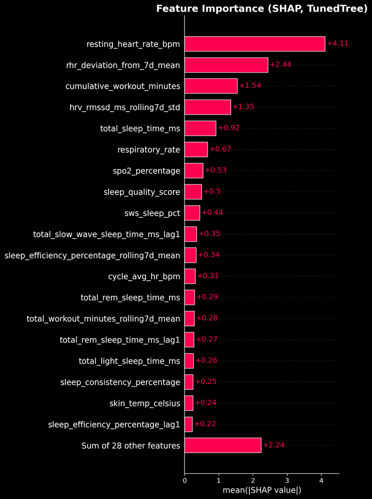

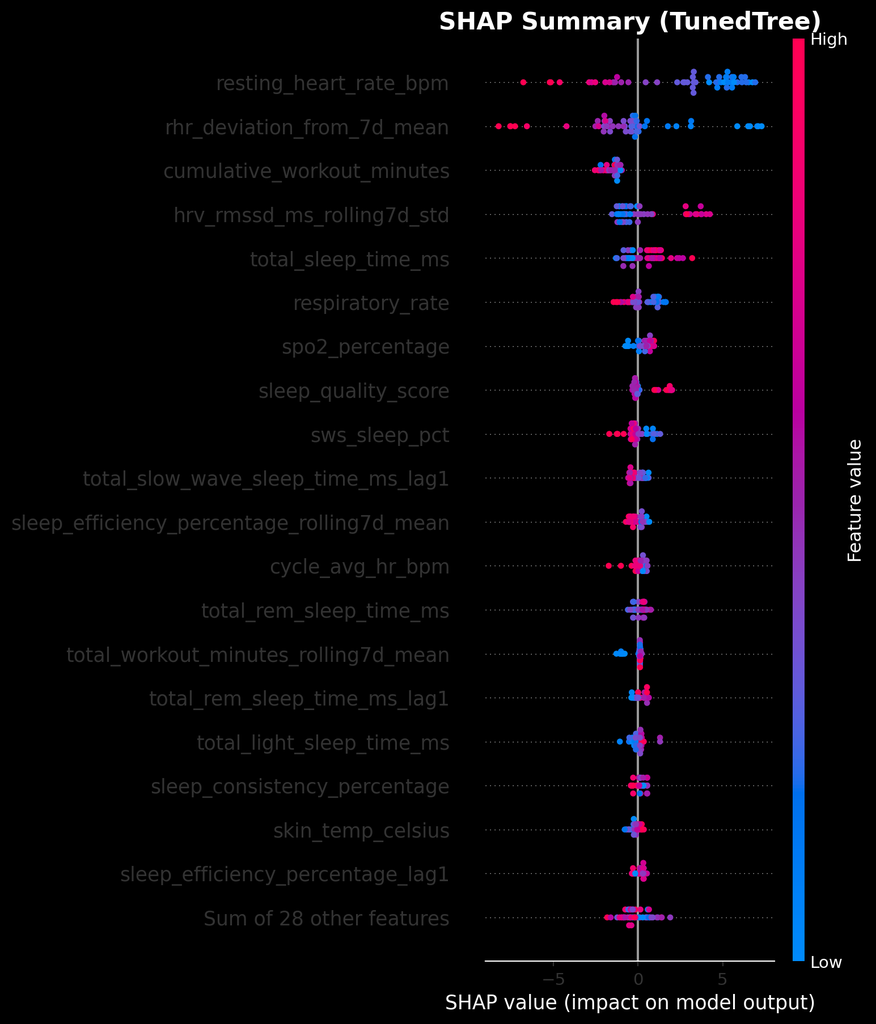

```python
print("⚙️  Calculating feature attributions...")

# Helper to ensure we have a model to interpret
_tree_model = None
if 'best_tree_model' in globals():
    _tree_model = best_tree_model
elif 'xgb_model' in globals():
    _tree_model = xgb_model

if _tree_model is None:
    print("⏭️ No tree model available to interpret.")
else:
    # Try SHAP first
    _has_shap = 'shap' in globals()
    if _has_shap:
        try:
            # Case A: XGBoost model → use TreeExplainer
            if 'xgb' in globals() and hasattr(xgb, 'XGBRegressor') and isinstance(_tree_model, xgb.XGBRegressor):
                print("🧭 Using SHAP TreeExplainer for XGBoost...")
                explainer = shap.TreeExplainer(_tree_model)
                shap_values = explainer.shap_values(X_test_tree)

                # Bar plot (mean |SHAP|)
                shap.summary_plot(
                    shap_values,
                    X_test_tree,
                    plot_type="bar",
                    show=False
                )
                plt.title('Feature Importance (SHAP, XGBoost)', fontsize=16, fontweight='bold')
                plt.tight_layout()
                plt.show()

                # Beeswarm
                shap.summary_plot(
                    shap_values,
                    X_test_tree,
                    show=False
                )
                plt.title('SHAP Summary (XGBoost)', fontsize=16, fontweight='bold')
                plt.tight_layout()
                plt.show()

            else:
                # Case B: scikit-learn tree model (e.g., HistGradientBoosting)
                print("🧭 Using SHAP generic Explainer for scikit-learn tree model...")
                explainer = shap.Explainer(_tree_model, X_train_tree)
                shap_values = explainer(X_test_tree)

                # Bar plot (mean |SHAP|)
                shap.plots.bar(shap_values, max_display=20, show=False)
                plt.title('Feature Importance (SHAP, TunedTree)', fontsize=16, fontweight='bold')
                plt.tight_layout()
                plt.show()

                # Beeswarm
                shap.plots.beeswarm(shap_values, max_display=20, show=False)
                plt.title('SHAP Summary (TunedTree)', fontsize=16, fontweight='bold')
                plt.tight_layout()
                plt.show()

        except Exception as e:
            print(f"⚠️ SHAP failed: {e}")
            _has_shap = False

    if not _has_shap:
        # Fallback: permutation importance
        print("⏭️ SHAP unavailable → using permutation importance fallback...")
        from sklearn.inspection import permutation_importance

        r = permutation_importance(_tree_model, X_test_tree, y_test_tree, n_repeats=20, random_state=42, n_jobs=-1)
        importances = pd.Series(r.importances_mean, index=X_test_tree.columns).sort_values(ascending=True)

        fig, ax = plt.subplots(figsize=(8, 8))
        ax.barh(importances.index[-25:], importances.values[-25:], color='#00D9FF', alpha=0.85)
        ax.set_title('Permutation Importance (Top 25 Features)', fontsize=16, fontweight='bold')
        ax.set_xlabel('Mean Importance (Δ RMSE)', fontsize=12)
        ax.grid(axis='x', alpha=0.3)
        plt.tight_layout()
        plt.show()

        print("💡 Interpretation: Higher bars = features that worsen error most when shuffled (more important). Sign indicates direction is not provided; use PDP for direction if needed.")
```

To showcase the model’s explanatory power on a granular level, we can generate SHAP waterfall plots for specific days in the test set. Let’s analyze the days with the **lowest** and **highest** HRV to see what drove those outcomes.

**Explain individual predictions with SHAP waterfall plots**

Deconstructing a Low HRV Day

```
Analyzing the lowest HRV day: 2025-09-29 (HRV: 46.3 ms)
```

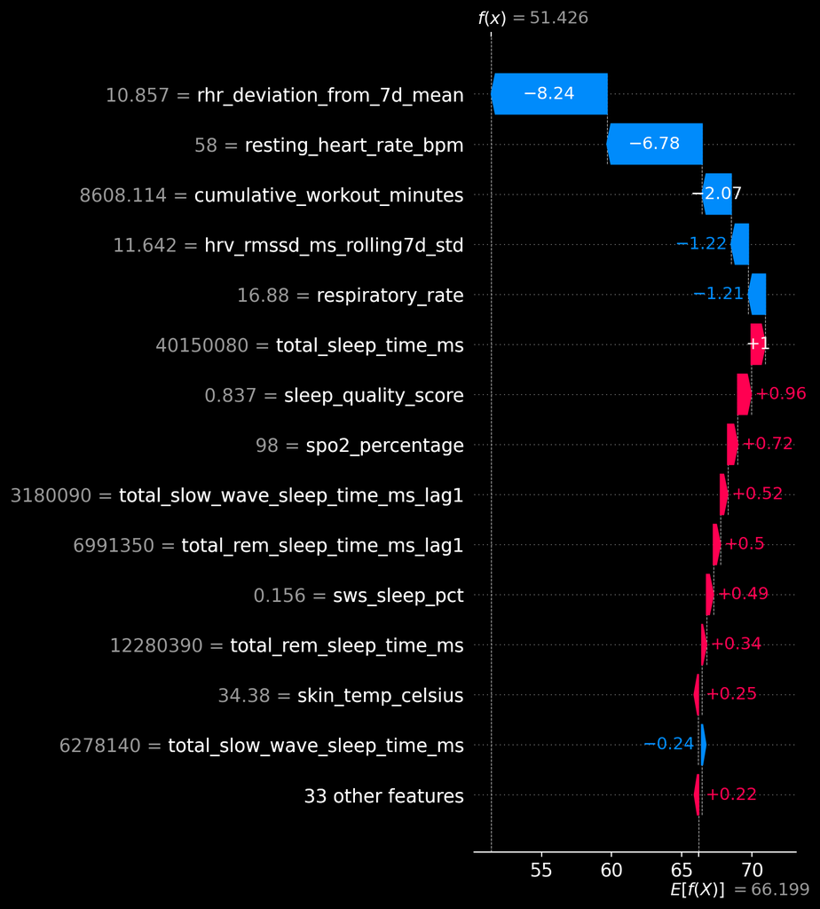

Deconstructing a High HRV Day

```
Analyzing the highest HRV day: 2025-10-02 (HRV: 100.9 ms)
```

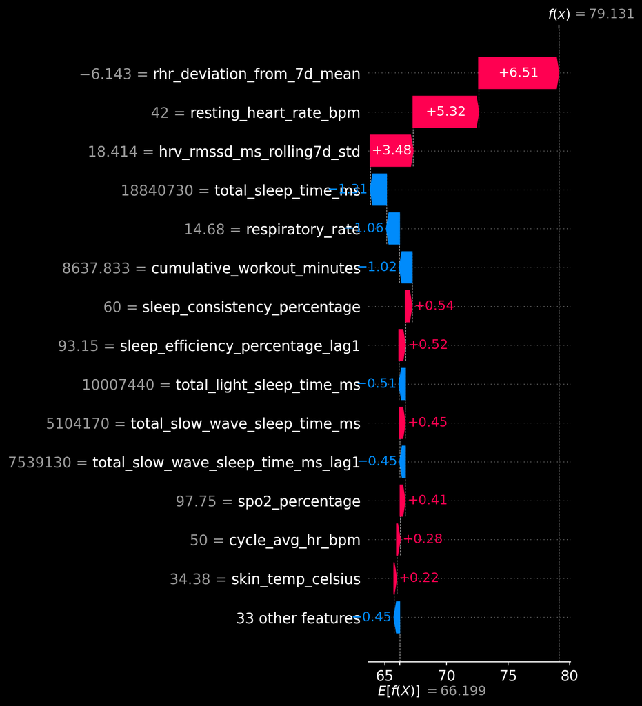

```python
# Only run if we have SHAP and a tree model
if 'explainer' in globals() and 'shap_values' in globals():
    display(Markdown("### Deconstructing a Low HRV Day"))

    # Find the day with the lowest HRV in the test set
    worst_day_idx = y_test_tree.idxmin()

    # For XGBoost models, shap_values is a numpy array
    if isinstance(shap_values, np.ndarray):
        test_idx_position = X_test_tree.index.get_loc(worst_day_idx)
        worst_day_shap_values = shap_values[test_idx_position]

        print(f"Analyzing the lowest HRV day: {test_tree.loc[worst_day_idx, 'cycle_date'].date()} (HRV: {y_test_tree.loc[worst_day_idx]:.1f} ms)")

        shap.waterfall_plot(shap.Explanation(
            values=worst_day_shap_values,
            base_values=explainer.expected_value,
            data=X_test_tree.loc[worst_day_idx].values,
            feature_names=X_test_tree.columns.tolist()
        ))
    else:
        # For sklearn models, shap_values is an Explanation object
        worst_day_shap = shap_values[X_test_tree.index.get_loc(worst_day_idx)]

        print(f"Analyzing the lowest HRV day: {test_tree.loc[worst_day_idx, 'cycle_date'].date()} (HRV: {y_test_tree.loc[worst_day_idx]:.1f} ms)")

        shap.plots.waterfall(worst_day_shap, max_display=15, show=False)
        plt.tight_layout()
        plt.show()

    display(Markdown("### Deconstructing a High HRV Day"))

    # Find the day with the highest HRV in the test set
    best_day_idx = y_test_tree.idxmax()

    if isinstance(shap_values, np.ndarray):
        test_idx_position = X_test_tree.index.get_loc(best_day_idx)
        best_day_shap_values = shap_values[test_idx_position]

        print(f"Analyzing the highest HRV day: {test_tree.loc[best_day_idx, 'cycle_date'].date()} (HRV: {y_test_tree.loc[best_day_idx]:.1f} ms)")

        shap.waterfall_plot(shap.Explanation(
            values=best_day_shap_values,
            base_values=explainer.expected_value,
            data=X_test_tree.loc[best_day_idx].values,
            feature_names=X_test_tree.columns.tolist()
        ))
    else:
        best_day_shap = shap_values[X_test_tree.index.get_loc(best_day_idx)]

        print(f"Analyzing the highest HRV day: {test_tree.loc[best_day_idx, 'cycle_date'].date()} (HRV: {y_test_tree.loc[best_day_idx]:.1f} ms)")

        shap.plots.waterfall(best_day_shap, max_display=15, show=False)
        plt.tight_layout()
        plt.show()
else:
    print("⏭️ SHAP waterfall plots require SHAP values to be calculated first.")
```

# Phase 4: Synthesis & Actionable Protocol

This final phase synthesizes the findings from both the Lasso and tree-based models and translates them into a practical, data-driven personal protocol to optimize recovery and performance.

## 4.1 Synthesis of Models: What Did We Learn?

By comparing our simple, interpretable Lasso model with the powerful, non-linear tree-based model, we can build a highly confident understanding of the key HRV drivers.

## 4.2 Actionable Insights & Personal Protocol

The model’s findings can be distilled into a simple, actionable protocol. This moves the project from descriptive analysis to a prescriptive tool for self-improvement.

**1. The RHR Deviation Rule (The “Red Flag” Detector):** - **Finding:** The feature `rhr_deviation_from_7d_mean` is a powerful negative driver, signaling acute stress. - **Protocol:** If my morning RHR is **2+ bpm above** my 7-day average, I will treat it as a signal of systemic fatigue or impending illness. That day’s training will be shifted to active recovery (e.g., walking, mobility), regardless of the original plan.

By adhering to this data-driven protocol, the insights from this analysis can be directly applied to optimize daily well-being and long-term athletic adaptation.